# Introducción a la autocorrelación espacial

Autor

Afiliación

[Gabriel Andrade Ponce](https://www.researchgate.net/profile/Gabriel-Andrade-Ponce)

Estudiante de Doctorado -Red de Biología y Conservación de Vertebrados - INECOL

[@Gatorco_AP](https://twitter.com/Gatorco_AP) [@gpandradep](https://github.com/gpandradep) gpandradep@gmail.com

# Bienvenidos 🤟🤟

En esta página encontrarán la presentación y los scripts para un pequeño ejercicio donde intentaremos entender de que se trata la autocorrelación espacial y como verificarla en nuestros datos.

Por favor sigue las instrucciones para descargar los paquetes y scripts.

# Instrucciones 🧐

## Instalación de paquetes

Usen el siguiente código parra instalar los paquetes necesarios. También pueden instalarlos uno por uno.

```r
install.packages(c("tidyverse", # Manejo de datos y gráficas
                   "sp", # Manejo de datos espaciales
                   "sf", # Manejo de datos espaciales
                   "AICcmodavg", # selección de modelos
                   "DHARMa", # Diagnóstico de modelos
                   "MASS", # Extensión para glm nb
                   "pgirmess", #correlogramas
                   "ncf", # correlogramas
                   "gghighlight", # destacar figuras
                   "showtext", # Añadir texto
                   "ggtext", # markdown ggplot
                   "ggspatial", # objetos espaciales ggplot
                   "leaflet" #mapas interactivos
                   ))
```

## Descargar datos y script

Puedes descargar el proyecto en R que incluye los datos y los scripts. Para ello usa el siguiente boton y descomprime la carpeta donde lo desees

# Presentación 📽️

[interactive chart not shown]

Diapositivas completas

# Código 💻

## Librerías

```r
library(tidyverse) # Easily Install and Load the 'Tidyverse'
library(sp) # Classes and Methods for Spatial Data
library(sf) # Simple Features for R
library(gghighlight) # Highlight Lines and Points in 'ggplot2'
library(showtext) # Using Fonts More Easily in R Graphs
library(ggtext) # Improved Text Rendering Support for 'ggplot2'
library(ggspatial) # Spatial Data Framework for ggplot2
library(leaflet) # Create Interactive Web Maps with the JavaScript 'Leaflet' Library
library(AICcmodavg) # Model Selection and Multimodel Inference Based on (Q)AIC(c)
library(DHARMa) # Residual Diagnostics for Hierarchical (Multi-Level / Mixed) Regression Models
library(MASS) # Support Functions and Datasets for Venables and Ripley's MASS

# Paquetes para correlogramas
library(pgirmess) # Spatial Analysis and Data Mining for Field Ecologists
library(ncf) # Spatial Covariance Functions
font_add_google("Fira Sans", "firasans") # Familia de tipo de letra
showtext_auto()
```

## Cargar datos

```r
CTtable <- read.csv("Data/CTtable.csv") %>%  # Base de coordenadas de cámaras
 dplyr::select(Station, utm_x, utm_y ) # Seleccionar columnas que usaremos
```

| Station | utm_x | utm_y |
| --- | --- | --- |
| C1T2P1 | 693961 | 2009932 |
| C1T2P11 | 693553 | 2009643 |
| C1T2P21 | 693144 | 2009355 |
| C1T4P1 | 693673 | 2010340 |
| C1T4P11 | 693264 | 2010052 |
| C1T4P21 | 692856 | 2009763 |

```r
events_by_species <- read_csv("Data/surveyReport/events_by_species.csv") %>%
  type.convert(n_events= col_double(), # Convertir tipo de columna
               n_stations= col_double()) %>% # Convertir tipo de columna
  mutate(Sp_n= paste("*",species,"*", " (n= ", n_events, " ) ", sep = "") ) # Columna para los nombres del eje
```

| species | n_events | n_stations | Sp_n |
| --- | --- | --- | --- |
| Aves | 704 | 42 | *Aves* (n= 704 ) |
| Bassariscus astutus | 3 | 2 | *Bassariscus astutus* (n= 3 ) |
| Canis latrans | 6 | 4 | *Canis latrans* (n= 6 ) |
| Canis lupus familiaris | 4 | 4 | *Canis lupus familiaris* (n= 4 ) |
| Capra hircus | 13 | 6 | *Capra hircus* (n= 13 ) |
| Conepatus leuconotus | 79 | 24 | *Conepatus leuconotus* (n= 79 ) |

```r
freq_reg <- read.csv("Data/surveyReport/events_by_station2.csv") %>% # Datos de registros por estación
  filter(Species == "Odocoileus virginianus") %>% # Filtrar especie
  left_join(CTtable, by= "Station") # Unir con la base da cámaras
```

| Station | Species | n_events | utm_x | utm_y |
| --- | --- | --- | --- | --- |
| C1T2P1 | Odocoileus virginianus | 0 | 693961 | 2009932 |
| C1T2P11 | Odocoileus virginianus | 3 | 693553 | 2009643 |
| C1T2P21 | Odocoileus virginianus | 10 | 693144 | 2009355 |
| C1T4P1 | Odocoileus virginianus | 1 | 693673 | 2010340 |
| C1T4P11 | Odocoileus virginianus | 12 | 693264 | 2010052 |
| C1T4P21 | Odocoileus virginianus | 0 | 692856 | 2009763 |

## Gráfico de detecciones

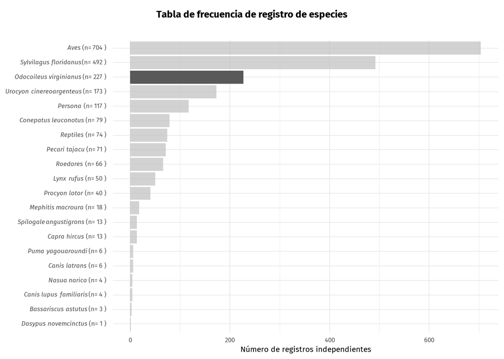

```r
(ndetectionplot <- ggplot(events_by_species, # Datos
                          aes(x= reorder(Sp_n,n_events), #Ordenar sp
                              y= n_events))+ # No. eventos
    geom_bar(stat= "identity")+  # Geometria
    gghighlight(species %in% c("Odocoileus virginianus"))+ # Señalar venados
    coord_flip()+ # Girar ejes
    labs(title = "Tabla de frecuencia de registro de especies", # Título
      y= "Número de registros independientes", # Eje y
      x= NULL)+ # Sin eje x
    theme_minimal()+ # Tema
    theme(text = element_text(family = 'firasans', size = 16), # tipo de letra
      plot.title.position = 'plot', # Marco de posición
      plot.title = element_text(face = 'bold', # Negrillas
        margin = margin(t = 2, r = 0, b = 7, l = 0, unit = "mm"), # Margenes
        hjust = 0.5), #posición central
      axis.text.y= element_markdown())) # Itálica nombre de especies
```

## Histograma de detecciónes

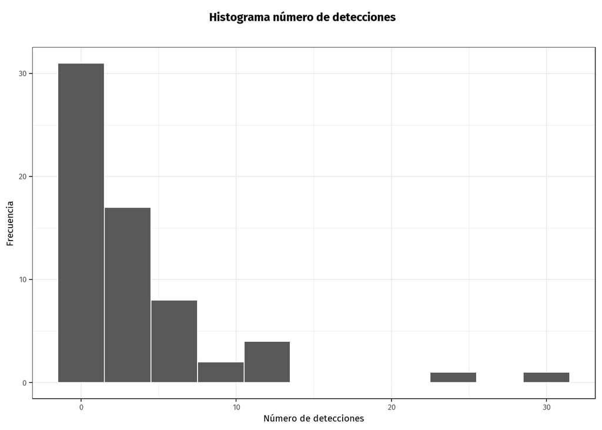

```r
(hist <- ggplot(freq_reg, aes(x= n_events))+ # Datos
    geom_histogram(binwidth = 3, color= "white")+ # Geometria
    labs(title = " Histograma número de detecciones",
      x= "Número de detecciones",
      y= "Frecuencia") +
    theme_bw()+ # Tema
    theme(text = element_text(family = 'firasans', size = 16), # tipo de letra
          plot.title.position = 'plot', # Marco de posición
          plot.title = element_text(face = 'bold', # Negrillas
                                    margin = margin(t = 2, r = 0, b = 7, l = 0, unit = "mm"), # Margenes
                                    hjust = 0.5)))
```

## Mapa de registros

```r
UMA <- st_read("Shape/UMA.shp") # Leer el shape de la UMA
# Es importante verificar que este en la misma proyección (CRS)
```

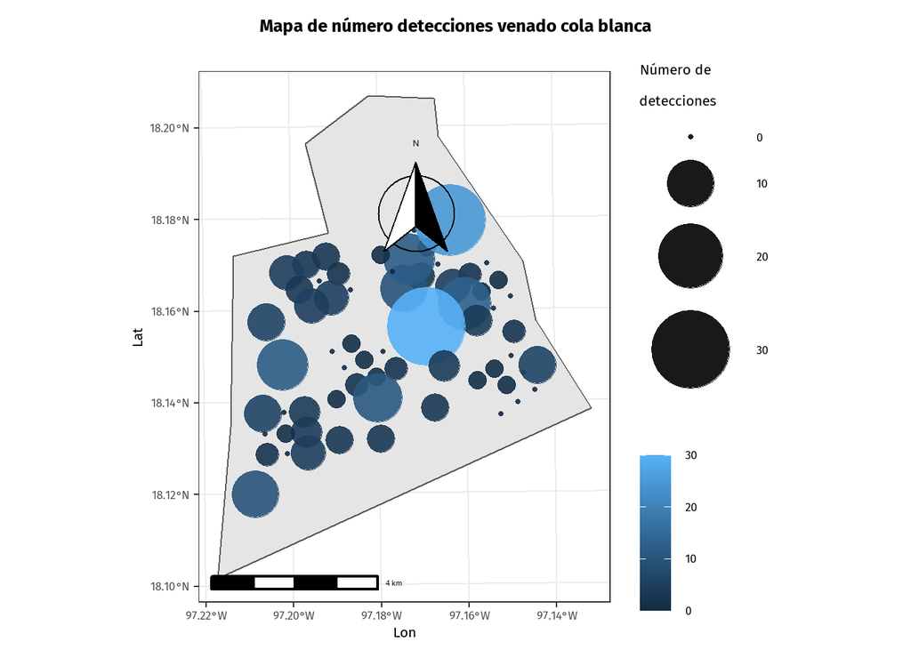

```r
(map <- ggplot(UMA)+ # shape de uma
  geom_sf()+ # Graficar objeto espacial
  geom_point(data= freq_reg, aes(x=utm_x, y=utm_y, # Agregar puntos
                 size= n_events, color= n_events), # Tamaño y color
             alpha=0.9)+ # Transparencia
  scale_size(range = c(1,20))+ # Escala del radio para los puntos
  labs(title= "Mapa de número detecciones venado cola blanca",
       y= "Lat",
       x= "Lon",
       size= "Número de \ndetecciones",
       color=NULL)+
    annotation_scale(location = "bl", width_hint = 0.5, # Barra de escala
                     line_width=2, tick_height=10) +
    annotation_north_arrow(location = "tr", # Flecha de norte
                           height = unit(2.5, "cm"), width = unit(2.5, "cm"),
                           pad_x = unit(1, "in"), pad_y = unit(0.5, "in"),
                           style = north_arrow_fancy_orienteering)+
  theme_bw()+
    theme(text=element_text(size=15, family = "special"))+
  theme(text = element_text(family = 'firasans', size = 16), # tipo de letra
        plot.title.position = 'plot', # Marco de posición
        plot.title = element_text(face = 'bold', # Negrillas
                                  margin = margin(t = 2, r = 0, b = 7, l = 0, unit = "mm"), # Margenes
                                  hjust = 0.5)))
```

## Modelando la frecuencia de registro de venados

Vamos a modelar la frecuencia de registros del venado por medio de un GLM *Poisson*. Uno de los supuestos de los GLMs es que las unidades espaciales son independientes, de manera que vamos a verificarlo. Adicionalmente, vamos a probar algunas covariables que nos ayuden a explicar la distribución espacial de los registros. La no inclusión de una variable importante puede generar patrones en los residuales.

Vamos a cargar una base de datos de covariables

```r
covs.data<-read.csv("Data/covars.csv", header=TRUE) %>% # covariables
  dplyr::select(-X) # eliminar columna X

covs.data$Cluster<- as.character(covs.data$Cluster) # cluster es categórica

### Separar las variables númericas y categóricas
cov.num <- covs.data %>%
  dplyr::select(where(is.numeric)) %>% # Seleccionar columnas numéricas
  scale() %>%  # estandarizar
  as.data.frame()

cov.fac <- covs.data %>%
  dplyr::select(where(is.character)) # Seleccionar variables de caracter

### Unir las bases
sp_glmdata <- data.frame(cov.fac, cov.num) %>% # Unir covariables
  right_join(freq_reg, by= "Station")# Unir con la base de rgistros
```

| Station | Cam | Habitat | Cluster | Vertcover_50 | Dcrops | MSAVI | Slope | Effort | Dpop_G | Species | n_events | utm_x | utm_y |
| --- | --- | --- | --- | --- | --- | --- | --- | --- | --- | --- | --- | --- | --- |
| C1T2P1 | MoultrieA30 | Scrub | 1 | -0.4744602 | 0.6765368 | 0.7316819 | -0.2195550 | -0.2080680 | -0.4260974 | Odocoileus virginianus | 0 | 693961 | 2009932 |
| C1T2P11 | Moultrie | Scrub | 1 | 0.6519157 | 1.4620448 | -0.8666152 | -0.9927301 | -1.4605398 | -0.3167450 | Odocoileus virginianus | 3 | 693553 | 2009643 |
| C1T2P21 | MoultrieA30 | Scrub | 1 | -0.9243340 | 2.2193059 | -0.5838870 | -1.0258694 | -0.0719298 | -0.1805434 | Odocoileus virginianus | 10 | 693144 | 2009355 |
| C1T4P1 | Primos | Columnar | 1 | -0.9243340 | 0.4603495 | -0.1430110 | 1.4183658 | -0.8887592 | -0.1922714 | Odocoileus virginianus | 1 | 693673 | 2010340 |
| C1T4P11 | MoultrieA30 | Scrub | 1 | -1.1509622 | 1.1723154 | 0.2129457 | -0.0597006 | -0.0719298 | -0.0948151 | Odocoileus virginianus | 12 | 693264 | 2010052 |
| C1T4P21 | Primos | Scrub | 1 | 0.6519157 | 1.9052628 | 0.5284530 | -1.0258694 | -0.0719298 | 0.0268169 | Odocoileus virginianus | 0 | 692856 | 2009763 |

Ahora ajustemos algunos modelos

```r
## Modelos lineales generalizados

# sin variables
m0 <- glm(n_events~ 1, # Formula
          data = sp_glmdata, # datos
          family = "poisson") # tipo de distribución

# la frecuencia de registro afectada por la distancia a cultivo
m1 <- glm(n_events~ Dcrops,
          data = sp_glmdata, family = "poisson")

# la frecuencia de registro afectada por el verdor de la vegetación
m2 <- glm(n_events~ MSAVI,
                    data = sp_glmdata, family = "poisson")

# la frecuencia de registro afectada por la pendiente
m3 <- glm(n_events~ Slope,
                    data = sp_glmdata, family = "poisson")
          #family = "poisson")

# la frecuencia de registro afectada por la distancia a poblados
m4 <- glm(n_events~ Dpop_G,
                    data = sp_glmdata, family = "poisson")


# la frecuencia de registro afectada por el tipo de habitat
m5 <- glm(n_events~ Habitat,
             data = sp_glmdata, family = "poisson" )
```

Seleccionamos el “mejor” con el criterio de información de Akaike

```r
lista_mods <- list(m0, m1, m2, m3, m4, m5)
mod_names <- c("freq~ 1",
               "freq~ D_cultivos",
               "freq~ MSAVI",
               "freq~ Slope",
               "freq~ D_poblado",
               "freq~ Habitat"
               )

AIC <- aictab(lista_mods, # Lista de modelos
              modnames = mod_names,  # nombres
              second.ord = F, # Seleccionar AIC
              sort = T) # Ordenar por menor valor
```

```r
knitr::kable(AIC)
```

|  | Modnames | K | AIC | Delta_AIC | ModelLik | AICWt | LL | Cum.Wt |
| --- | --- | --- | --- | --- | --- | --- | --- | --- |
| 6 | freq~ Habitat | 4 | 440.0256 | 0.00000 | 1 | 1 | -216.0128 | 1 |
| 3 | freq~ MSAVI | 2 | 497.6351 | 57.60950 | 0 | 0 | -246.8175 | 1 |
| 2 | freq~ D_cultivos | 2 | 511.1291 | 71.10355 | 0 | 0 | -253.5646 | 1 |
| 5 | freq~ D_poblado | 2 | 512.4230 | 72.39737 | 0 | 0 | -254.2115 | 1 |
| 4 | freq~ Slope | 2 | 512.4941 | 72.46851 | 0 | 0 | -254.2471 | 1 |
| 1 | freq~ 1 | 1 | 513.1820 | 73.15641 | 0 | 0 | -255.5910 | 1 |

Podemos inspeccionar el mejor modelo

```r
# para inspeccionar el modelo usar la función summary
summary(m5)
```

```
Call:
glm(formula = n_events ~ Habitat, family = "poisson", data = sp_glmdata)

Deviance Residuals:
    Min       1Q   Median       3Q      Max
-2.5702  -2.4202  -0.7741   0.4265   7.9420

Coefficients:
             Estimate Std. Error z value Pr(>|z|)
(Intercept)    1.0745     0.1104   9.730   <2e-16 ***
Habitatcrop    0.0241     0.4229   0.057    0.955
Habitatsalt    2.3267     0.2134  10.904   <2e-16 ***
HabitatScrub   0.1203     0.1462   0.823    0.410
---
Signif. codes:  0 '***' 0.001 '**' 0.01 '*' 0.05 '.' 0.1 ' ' 1

(Dispersion parameter for poisson family taken to be 1)

    Null deviance: 373.16  on 63  degrees of freedom
Residual deviance: 294.00  on 60  degrees of freedom
AIC: 440.03

Number of Fisher Scoring iterations: 6
```

Dado al carácter relativo del AIC es necesario verificar que el mejor modelo es un buen modelo. Un mal ajuste puede ser causado por la existencia de autocorrelación en los residuales.

## Residuales del mejor modelo

Debido a que es un GLM de familia poisson los residuales no están definidos como en un modelo lineal simple. La función simulateResidual permite obtener una aproximación de residuales escalados para este tipo de modelos.

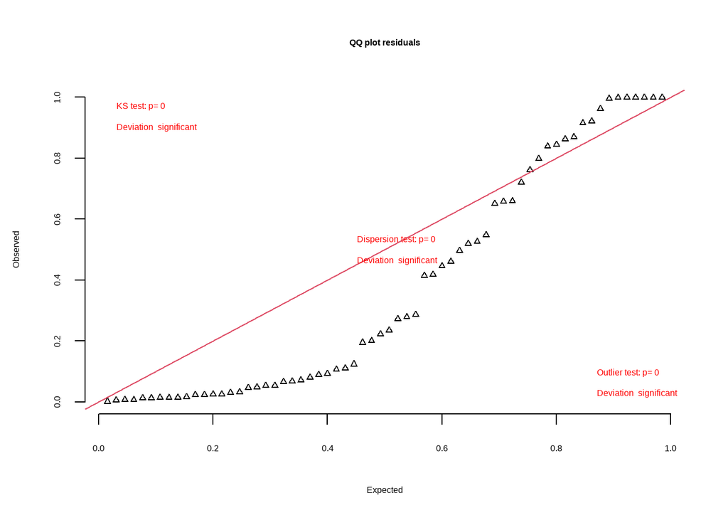

```r
# Verificamos visualmente que el modelo cumpla los requisitos de la distribución
residuales <- simulateResiduals(fittedModel = m5, plot =F)

plotQQunif(residuales)
```

Creamos un data set con los residuales y las coordenadas

```r
# Creamos el data.frame para el correlograma
data_resm5 <- data.frame(res=residuals(residuales), # Residuales que creamos
                         x= sp_glmdata$utm_x,# coordenadas en x
                         y= sp_glmdata$utm_y) # coordenadas en y
```

| res | x | y |
| --- | --- | --- |
| 0.0005904 | 693961 | 2009932 |
| 0.4597318 | 693553 | 2009643 |
| 1.0000000 | 693144 | 2009355 |
| 0.2011827 | 693673 | 2010340 |
| 1.0000000 | 693264 | 2010052 |
| 0.0312027 | 692856 | 2009763 |

Mapa de los residuales

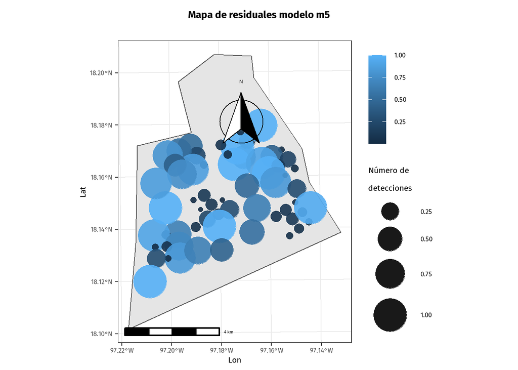

```r
(map_res <- ggplot(UMA)+ # shape de uma
    geom_sf()+ # Graficar objeto espacial
    geom_point(data= data_resm5, aes(x=x, y=y, # Agregar puntos
                                   size= res, color= res), # Tamaño y color
               alpha=0.9)+ # Transparencia
    scale_size(range = c(1,15))+ # Escala del radio para los puntos
    labs(title= "Mapa de residuales modelo m5",
         y= "Lat",
         x= "Lon",
         size= "Número de \ndetecciones",
         color=NULL)+
    annotation_scale(location = "bl", width_hint = 0.5, # Barra de escala
                     line_width=2, tick_height=10) +
    annotation_north_arrow(location = "tr", # Flecha de norte
                           height = unit(2.5, "cm"), width = unit(2.5, "cm"),
                           pad_x = unit(1, "in"), pad_y = unit(0.5, "in"),
                           style = north_arrow_fancy_orienteering)+
    theme_bw()+
    theme(text=element_text(size=15, family = "special"))+
    theme(text = element_text(family = 'firasans', size = 16), # tipo de letra
          plot.title.position = 'plot', # Marco de posición
          plot.title = element_text(face = 'bold', # Negrillas
                                    margin = margin(t = 2, r = 0, b = 7, l = 0, unit = "mm"), # Margenes
                                    hjust = 0.5)))
```

## Verificando autocorrelación espacial

El test de Moran I básicamente es la extensión de una prueba de correlación de Pearson para las diferentes distancias entre unidades de muestreo. El objetivo es estimar el grado de correlación espacial de una misma variable. Cuando ploteamos el valor de I para las diferentes distancias tenemos un correlograma espacial

Hay diferentes paquetes que permiten generar los correlogramas, cada una tiene sus virtudes y puede ser más conveniente o no, dependiendo de la capácidad de programación del usuario y los datos.

Primero vamos a generar la matriz de distancia. Para asegurar que cada categoría de distancia tenga suficientes pares se recomienda trabajar con 2/3 de la máxima distancia. En este caso la máxima distancia es ~ 8km

```r
Wdist <- data.frame(x= sp_glmdata$utm_x,
                    y= sp_glmdata$utm_y) %>%
  dist() %>%
  as.matrix()
maxd <- 2/3* max(Wdist)
maxd
```

```
[1] 5410.514
```

### Paquete *pgirmess*

`pgirmess` llama las funciones de `spdep` con una sintaxis mas amigable, lo que a su vez lo hace menos flexible. Esta aproximación asume que la variable de respuesta se distribuye de manera normal para calcular los p valores

```r
pgirmess_correg <- pgirmess::correlog(coords = cbind(data_resm5$x, # coordenada x
                                                     data_resm5$y), # coordenada y
                                      z= data_resm5$res, # residuales
                                      method = "Moran", # Tipo demétodo
                                      nbclass = NULL) # Automáticamente el número de pares
```

| dist.class | coef | p.value | n |
| --- | --- | --- | --- |
| 721.7898 | 0.0294411 | 0.2755318 | 356 |
| 1364.7448 | -0.0651344 | 0.7410662 | 368 |
| 2007.6997 | -0.0740384 | 0.8288021 | 526 |
| 2650.6546 | -0.0101852 | 0.4619799 | 560 |
| 3293.6096 | 0.0479433 | 0.1357293 | 548 |
| 3936.5645 | 0.1084853 | 0.0224445 | 496 |
| 4579.5194 | 0.0807245 | 0.0852875 | 432 |
| 5222.4744 | -0.0904677 | 0.8024336 | 308 |
| 5865.4293 | -0.1115091 | 0.8297352 | 264 |
| 6508.3842 | 0.0223829 | 0.3466816 | 126 |
| 7151.3392 | -0.3394159 | 0.9428442 | 38 |
| 7794.2941 | -0.2052650 | 0.5430549 | 10 |

### Paquete ncf

La ventaja del paquete ncf es que permite generar correlogramas usando un test de significancia no paramétrico, por medio simulaciones Monte Carlo.

```r
ncf_correg <- ncf::correlog(x=data_resm5$x, # coordenadas en x
                            y=data_resm5$y, # coordenadas en y
                            z=data_resm5$res, # variable de interés,
                            latlon =  FALSE, #formato lat lon
                            na.rm=T, # en caso de NAs
                            increment = 700, # Distancia mínima de unidades
                            resamp=500) # Número de remuestreos
```

```
50  of  500
100  of  500
150  of  500
200  of  500
250  of  500
300  of  500
350  of  500
400  of  500
450  of  500
500  of  500
```

Modificamos data frame para la gráfica

```r
corbase <- data.frame(coef=ncf_correg$correlation,
                     dist.class= ncf_correg$mean.of.class,
                     p.value= ncf_correg$p,
                     n= ncf_correg$n )%>%
  bind_rows(as.data.frame(pgirmess_correg)) %>%
  mutate(package= c(rep("ncf", 12), rep("pgirmess",12)),
         p_valor= if_else(p.value<0.025, "significativo", "no-significativo"))
```

|  | coef | dist.class | p.value | n | package | p_valor |
| --- | --- | --- | --- | --- | --- | --- |
| 1 | 0.0858466 | 527.4675 | 0.1696607 | 83 | ncf | no-significativo |
| 2 | 0.0267224 | 1044.7161 | 0.2574850 | 198 | ncf | no-significativo |
| 3 | -0.0938991 | 1756.1699 | 0.0898204 | 224 | ncf | no-significativo |
| 4 | -0.1348618 | 2438.5924 | 0.0159681 | 318 | ncf | significativo |
| 5 | 0.0710109 | 3154.0392 | 0.0558882 | 310 | ncf | no-significativo |
| 6 | 0.0799903 | 3842.9786 | 0.0499002 | 278 | ncf | no-significativo |
| 7 | 0.0749898 | 4526.0347 | 0.0718563 | 232 | ncf | no-significativo |
| 8 | -0.1415474 | 5243.6160 | 0.0598802 | 162 | ncf | no-significativo |
| 9 | -0.0848323 | 5908.4188 | 0.1916168 | 138 | ncf | no-significativo |
| 10 | 0.0546072 | 6567.7873 | 0.2774451 | 54 | ncf | no-significativo |
| 11 | -0.6117002 | 7212.9125 | 0.0079840 | 15 | ncf | significativo |
| 12 | -0.3202232 | 7906.3521 | 0.2634731 | 4 | ncf | no-significativo |
| …13 | 0.0294411 | 721.7898 | 0.2755318 | 356 | pgirmess | no-significativo |
| …14 | -0.0651344 | 1364.7448 | 0.7410662 | 368 | pgirmess | no-significativo |
| …15 | -0.0740384 | 2007.6997 | 0.8288021 | 526 | pgirmess | no-significativo |
| …16 | -0.0101852 | 2650.6546 | 0.4619799 | 560 | pgirmess | no-significativo |
| …17 | 0.0479433 | 3293.6096 | 0.1357293 | 548 | pgirmess | no-significativo |
| …18 | 0.1084853 | 3936.5645 | 0.0224445 | 496 | pgirmess | significativo |
| …19 | 0.0807245 | 4579.5194 | 0.0852875 | 432 | pgirmess | no-significativo |
| …20 | -0.0904677 | 5222.4744 | 0.8024336 | 308 | pgirmess | no-significativo |
| …21 | -0.1115091 | 5865.4293 | 0.8297352 | 264 | pgirmess | no-significativo |
| …22 | 0.0223829 | 6508.3842 | 0.3466816 | 126 | pgirmess | no-significativo |
| …23 | -0.3394159 | 7151.3392 | 0.9428442 | 38 | pgirmess | no-significativo |
| …24 | -0.2052650 | 7794.2941 | 0.5430549 | 10 | pgirmess | no-significativo |

Generamos nuestro gráfico

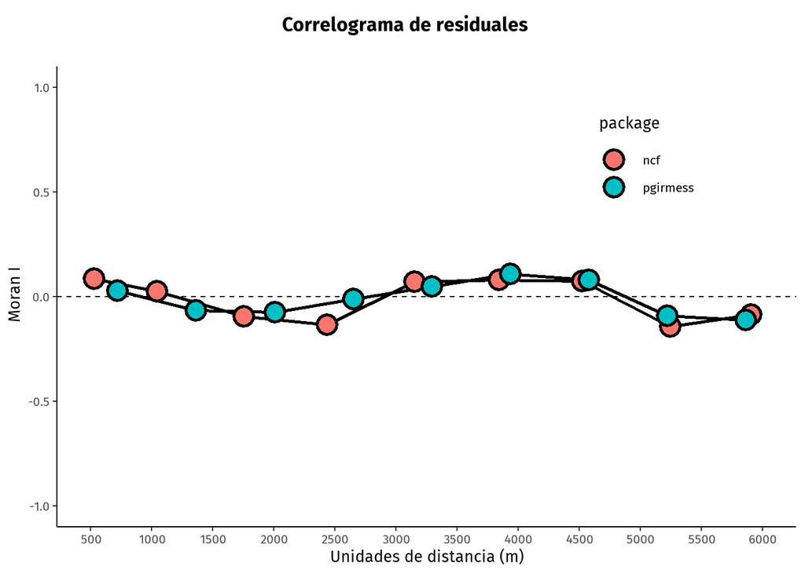

```r
(ggplot(corbase ,aes(x=dist.class, y=coef, group= package))+
    geom_hline(yintercept = 0, linetype= "dashed")+
    geom_line(size=0.9, colour="black")+
    geom_point(aes(fill= package, shape=p_valor),
               shape= 21, size=5, stroke = 1.5)+
    ylim(-1,1)+
    scale_x_continuous(breaks = seq(0,8000, by=500),limits = c(500,6000))+
    labs(x= "Unidades de distancia (m)", y= " Moran I",
         title = " Correlograma de residuales",
         colour= "Librería")+
    theme_classic()+
    theme(text = element_text(family = 'firasans', size = 20), # tipo de letra
          plot.title.position = 'plot', # Marco de posición
          plot.title = element_text(face = 'bold', # Negrillas
                                    margin = margin(t = 2, r = 0,
                                                    b = 7, l = 0,
                                                    unit = "mm"), # Margenes
                                    hjust = 0.5),
          legend.position = c(0.8, 0.8))) # posición de la legenda
```

### SP lines con ncf

`ncf` también permite ajustar splines cubicas por medio de bootstrap, en este caso no es necesario definir cortes de pares de distancias y permite obtener intervalos de confianza

```r
spline <- ncf::spline.correlog(x=data_resm5$x, # coordenadas en x
                               y=data_resm5$y, # coordenadas en y
                               z=data_resm5$res,
                               xmax = maxd, # distancia máxima
                               type = "boot",
                               resamp = 500)
```

```
50  of  500
100  of  500
150  of  500
200  of  500
250  of  500
300  of  500
350  of  500
400  of  500
450  of  500
500  of  500
```

Podemos hacer un plot de manera muy sencilla con `plot(spline)`, pero como yo soy terco la quiero hacer con ggplot.

Primero extraigo los valores de la gráfica

```r
spl_dist <- as.data.frame(spline[["boot"]][["boot.summary"]][["predicted"]][["x"]]) %>%
  t()

sp_base <- spline[["boot"]][["boot.summary"]][["predicted"]][["y"]][c(2,6,10),] %>% t() %>%
  as_tibble() %>%
  mutate(dist= spl_dist[,1])
```

| 0.025 | 0.5 | 0.975 | dist |
| --- | --- | --- | --- |
| -0.3358756 | 0.2151855 | 0.8007546 | 0.00000 |
| -0.3311834 | 0.2119576 | 0.7849898 | 18.09537 |
| -0.3264913 | 0.2081718 | 0.7691167 | 36.19073 |
| -0.3217992 | 0.2043483 | 0.7532436 | 54.28610 |
| -0.3152821 | 0.2007483 | 0.7373705 | 72.38146 |
| -0.3086233 | 0.1961292 | 0.7215707 | 90.47683 |

Ahora si el gráfico

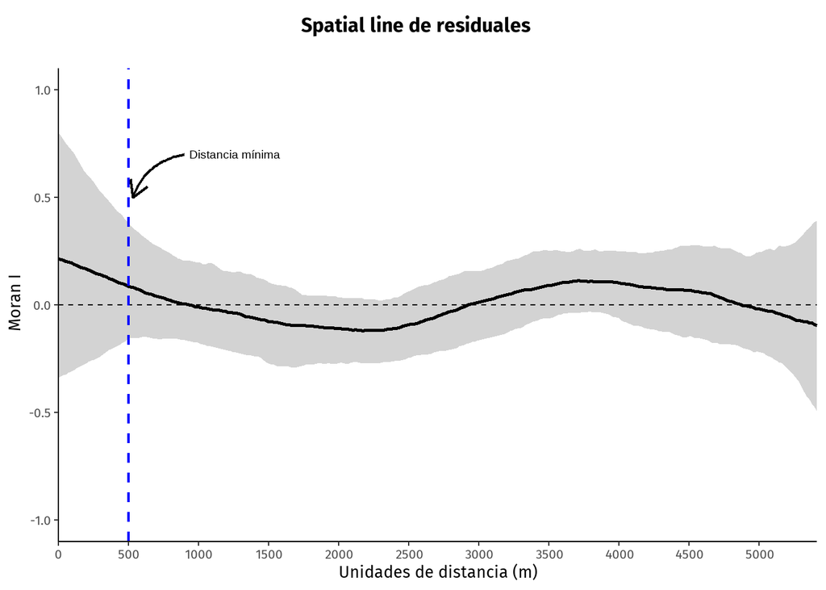

```r
(splineplot <- ggplot(sp_base, aes(x= dist, y= `0.5`))+
  geom_ribbon(aes(ymin= `0.025`, ymax= `0.975`),
              fill= "lightgray")+
  geom_line(size=1)+
  ylim(-1,1)+
  scale_x_continuous(breaks = seq(0,8000, by=500),
                     limits = c(min(sp_base$dist), max(sp_base$dist)),
                     expand = c(0,0))+
  geom_hline(yintercept = 0, linetype=2)+
  geom_vline(xintercept = 500, linetype=2, colour= "blue", size=0.8)+
  annotate(geom = "curve", x = 900, y = 0.7, xend = 530, yend = 0.5,
      curvature = .3, arrow = arrow(length = unit(4, "mm")), size=0.8) +
  annotate(geom = "text", x = 930, y = 0.7, size= 5,
           label = "Distancia mínima", hjust = "left")+
  labs(x= "Unidades de distancia (m)", y= " Moran I",
       title = " Spatial line de residuales")+
  theme_classic()+
  theme(text = element_text(family = 'firasans', size = 20), # tipo de letra
        plot.title.position = 'plot', # Marco de posición
        plot.title = element_text(face = 'bold', # Negrillas
                                  margin = margin(t = 2, r = 0,
                                                  b = 7, l = 0,
                                                  unit = "mm"), # Margenes
                                  hjust = 0.5),
        legend.position = c(0.8, 0.8))) # posición de la legenda
```

Lo que podemos concluir con todas las aproximaciones vistas es que parece ser que no hay una autocorrelación espacial fuerte de los residuales de nuestro modelo m5. Esto quiere decir que las desviaciones de la normalidad se deben a otro factor.

### Cambiando especificación del modelo

Ajustamos otro modelo que asumen una distribución de error *binomial negativa*. Con ello nos damos cuenta que el problema era el tipo de distribución.

```r
m5bn <- glm.nb(n_events~ Habitat, data = sp_glmdata)
```

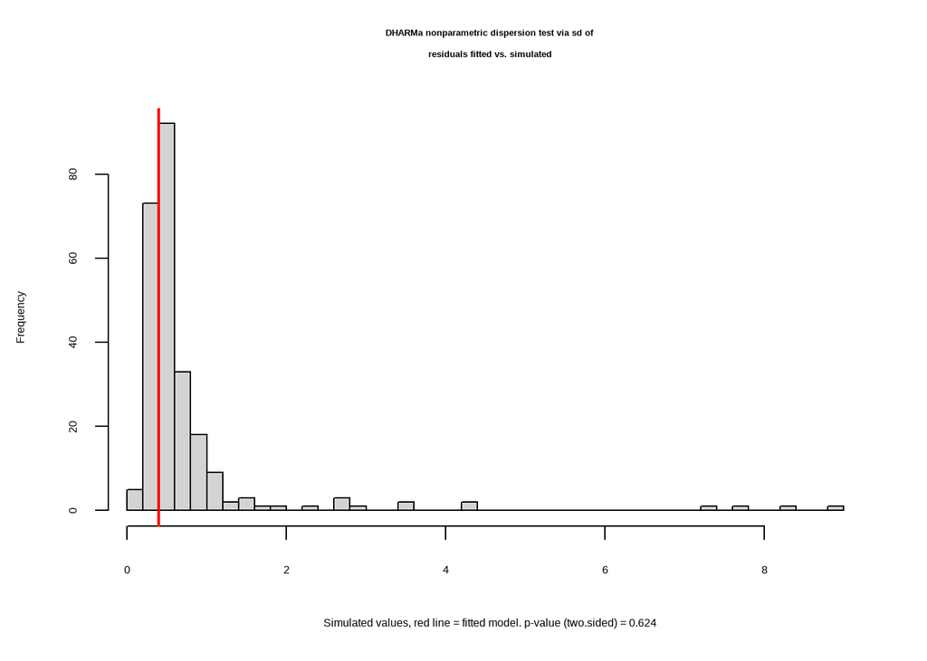

```
    DHARMa nonparametric dispersion test via sd of residuals fitted vs.
    simulated

data:  simulationOutput
dispersion = 0.52823, p-value = 0.624
alternative hypothesis: two.sided
```

```r
testDispersion(m5bn)
```

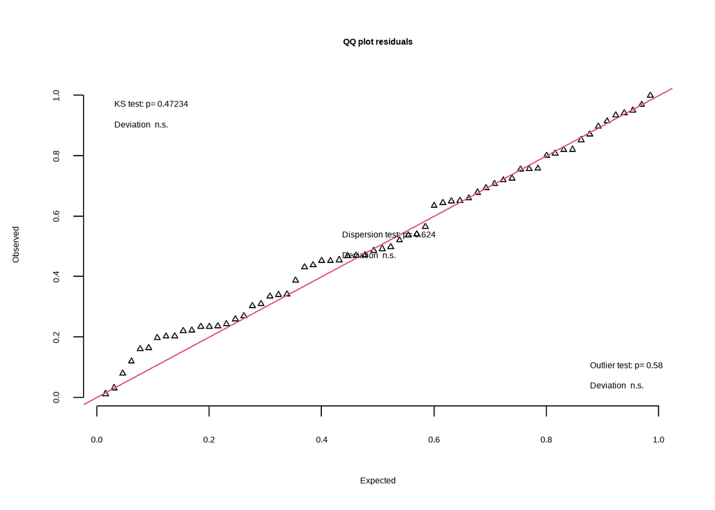

```r
residuales.bn <- simulateResiduals(fittedModel = m5bn, plot =F)

plotQQunif(residuales.bn)
```

Sorpresa 👽

# Esto es el inicio de la aventura

Esto fue un ejercicio sencillo, pero lidiar con la ACS merece realizar diversas lecturas en el tema, conocer los supuestos de las técnicas y aprender a interpretar los resultados.

En caso de encontrar ACS y dependiendo de los objetivos es recomendable usar herramientas como modelos de mínimos cuadrados generalizados (GLS), modelos mixtos, considerar a las coordenadas como covariables o modelos autorregresivos.

# Lecturas recomendadas

[figure not shown]

- 1- [Fox *et al.* 2015. Ecological Statistics: Contemporary theory and application](https://oxford.universitypressscholarship.com/view/10.1093/acprof:oso/9780199672547.001.0001/acprof-9780199672547)
- 2- [Plant 2019. Spatial Data Analysis in Ecology and Agriculture Using R](https://www.routledge.com/Spatial-Data-Analysis-in-Ecology-and-Agriculture-Using-R/Plant/p/book/9780367732325)
- 3- [Dorman *et al.* 2007. Methods to account for spatial autocorrelation in the analysis of species distributional data: a review](https://onlinelibrary.wiley.com/doi/10.1111/j.2007.0906-7590.05171.x)
- 4- [Kuhn & Dorman 2012. Less than eight (and a half) misconceptions of spatial analysis](https://onlinelibrary.wiley.com/doi/full/10.1111/j.1365-2699.2012.02707.x)
- 5- [Fletcher & Fortin 2018. Spatial Ecology and Conservation](https://link.springer.com/book/10.1007/978-3-030-01989-1)